# Лабораторная работа №5

Администрирование локальных сетей

Ибрахим Мохсейн Алькамаль

1032225432@rudn.ru

Российский университет дружбы народов

2026-03-14

# Информация

## Докладчик

- Ибрахим Мохсейн Алькамаль
- Российский университет дружбы народов

# Цель работы

Получить основные навыки по настройке VLAN на коммутаторах сети.

# “Конфигурирование VLAN”

## Настройка Trunk-портов на коммутаторе msk-donskaya-ealkamal-sw-1

- Настройка Trunk-портов на всех необходимых интерфейсах
- Интерфейсы **Gig0/1**, **Gig0/2** и **Fa0/1** переведены в режим **trunk**
- Протоколы линии успешно поднялись

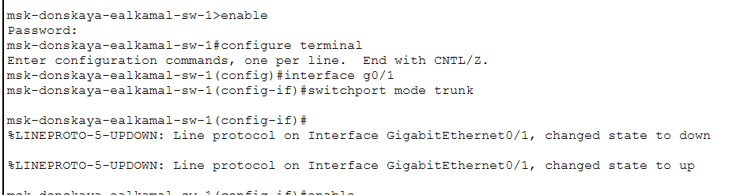

Рисунок 1: Настройка Trunk на интерфейсе g0/1 коммутатора msk-donskaya-sw-1

## Настройка оставшихся Trunk-портов на msk-donskaya-ealkamal-sw-1

- Интерфейсы **Gig0/2** и **Fa0/1** сконфигурированы как trunk
- Все соединения с соседними коммутаторами настроены корректно

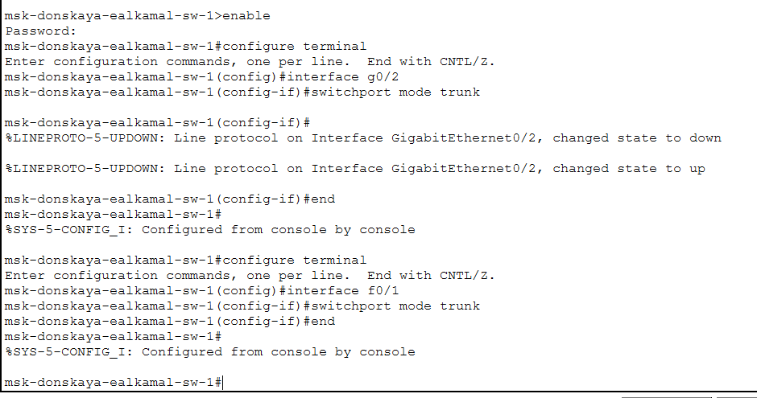

Рисунок 2: Настройка Trunk на интерфейсах g0/2 и f0/1 коммутатора msk-donskaya-sw-1

## Настройка VTP сервера и создание VLAN на msk-donskaya-ealkamal-sw-1

- Коммутатор настроен как **VTP Server**
- Установлены домен `donskaya` и пароль `cisco`
- Созданы VLAN:
  - **VLAN 2** - `management`
  - **VLAN 3** - `servers`
  - **VLAN 101** - `dk`
  - **VLAN 102** - `departaments`
  - **VLAN 103** - `adm`
  - **VLAN 104** - `other`

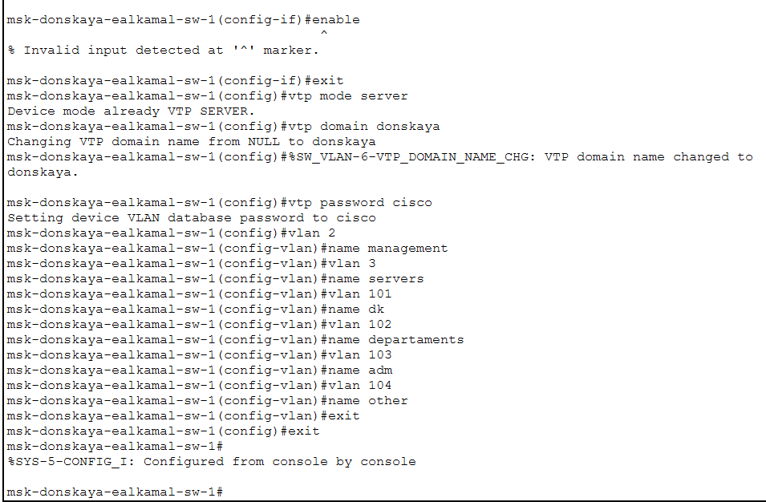

Рисунок 3: Настройка VTP сервера и создание VLAN на msk-donskaya-sw-1

## Настройка Trunk-портов на коммутаторе msk-donskaya-ealkamal-sw-2

- Интерфейс **Gig0/1** (соединение с `-sw-1`) переведён в режим trunk
- Интерфейс **Gig0/2** (соединение с `-sw-3`) переведён в режим trunk

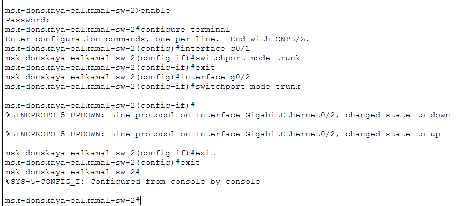

Рисунок 4: Настройка Trunk-портов на msk-donskaya-sw-2

## Настройка Trunk-порта на коммутаторе msk-donskaya-ealkamal-sw-4

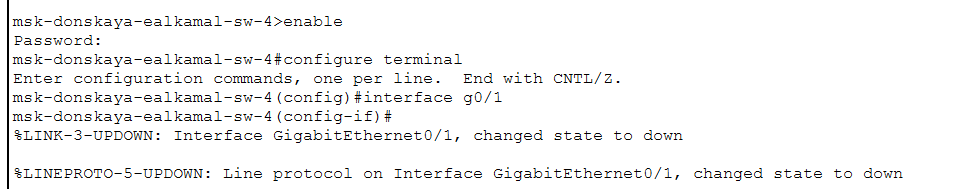

## Настройка Trunk-порта на коммутаторе msk-donskaya-ealkamal-sw-3

- Интерфейс **Gig0/1** (соединение с `msk-donskaya-sw-2`) переведён в режим **trunk**
- Конфигурация выполнена успешно

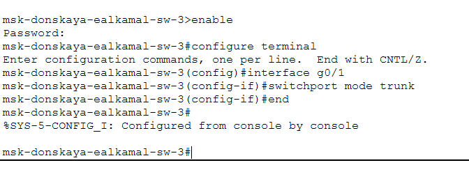

Рисунок 6: Настройка Trunk-порта на msk-donskaya-sw-3

## Настройка Trunk-порта на коммутаторе msk-pavlovskaya-ealkamal-sw-1

- Интерфейс **Fa0/24** (соединение с `msk-donskaya-sw-1`) переведён в режим **trunk**
- Обеспечивает передачу трафика нескольких VLAN между площадками

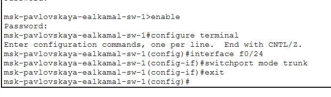

Рисунок 7: Настройка Trunk-порта на msk-pavlovskaya-sw-1

## Настройка VTP клиента и Access-портов на msk-donskaya-ealkamal-sw-2

- Коммутатор настроен как **VTP Client**
- Интерфейсы **Fa0/1** и **Fa0/2** настроены как **access-порты**
- Порта назначены в **VLAN 3 (servers)** для подключения веб-сервера и файлового сервера

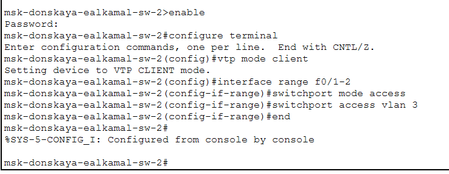

Рисунок 8: Настройка VTP Client и Access-портов на msk-donskaya-sw-2

## Настройка VTP клиента и Access-портов на коммутаторе msk-donskaya-ealkamal-sw-4

- Коммутатор настроен как **VTP Client**
- Интерфейсы распределены по VLAN:
  - **Fa0/1 – Fa0/5** → **VLAN 101 (dk)**
  - **Fa0/6 – Fa0/10** → **VLAN 102 (departaments)**
  - **Fa0/11 – Fa0/15** → **VLAN 103 (adm)**
  - **Fa0/16 – Fa0/24** → **VLAN 104 (other)**
- Все интерфейсы переведены в режим **access**

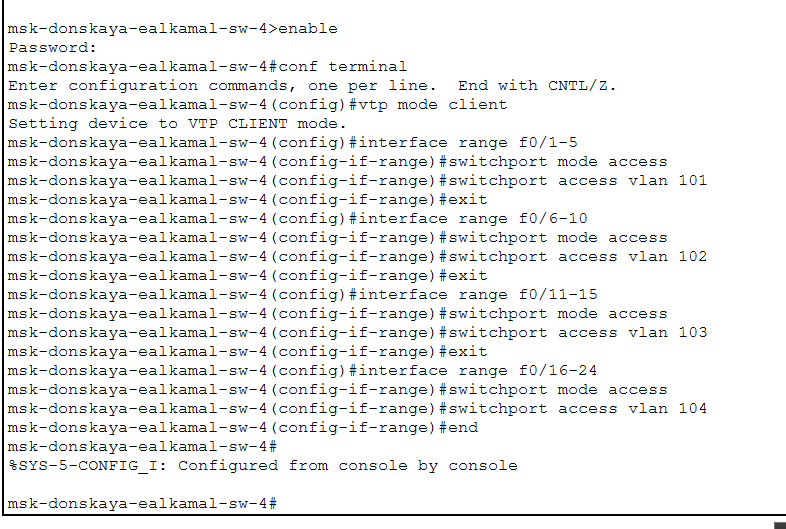

Рисунок 9: Настройка VTP Client и Access-портов на msk-donskaya-sw-4

## Настройка VTP клиента на msk-donskaya-ealkamal-sw-3

- Коммутатор настроен как **VTP Client**

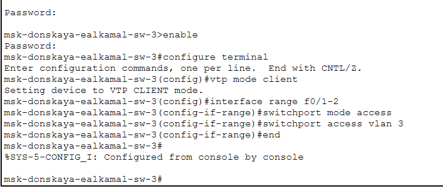

Рисунок 10: Настройка VTP Client на msk-donskaya-sw-3

## Настройка VTP клиента и Access-портов на msk-pavlovskaya-ealkamal-sw-1

- Коммутатор настроен как **VTP Client**
- Возникла ошибка при настройке **Fa0/24** (несоответствие типа порта)
- Конфигурация скорректирована:
  - **Fa0/1-15** → **VLAN 101 (dk)**
  - **Fa0/16-23** → подготовлены для соответствующих VLAN

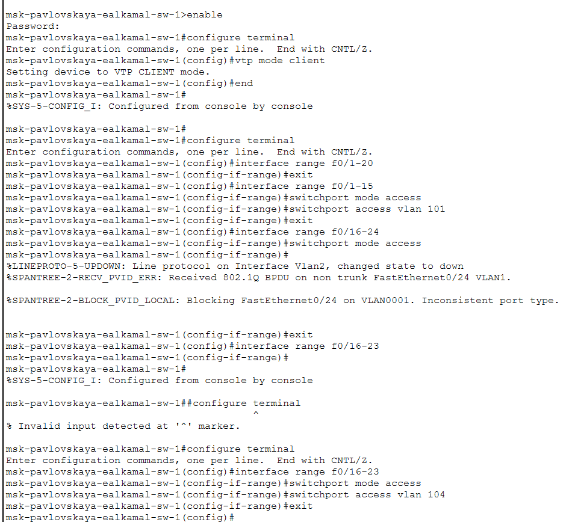

Рисунок 11: Настройка VTP Client и Access-портов на msk-pavlovskaya-sw-1

## Настройка IP-адресации на сервере Web

[figure not shown]

Рисунок 12: Настройка IP-адресации на сервере Web

## Настройка IP-адресации на сервере File

- **IP-адрес:** 10.128.0.3
- **Маска подсети:** 255.255.255.0
- **Шлюз по умолчанию:** 10.128.0.1
- Сервер в **VLAN 3 (servers)**, подключён к `msk-donskaya-sw-2`

[figure not shown]

Рисунок 13: Настройка IP-адресации на сервере File

## Настройка IP-адресации на сервере Mail

- **IP-адрес:** 10.128.0.4
- **Маска подсети:** 255.255.255.0
- **Шлюз по умолчанию:** 10.128.0.1
- Сервер в **VLAN 3 (servers)**, подключён к `msk-donskaya-sw-3`

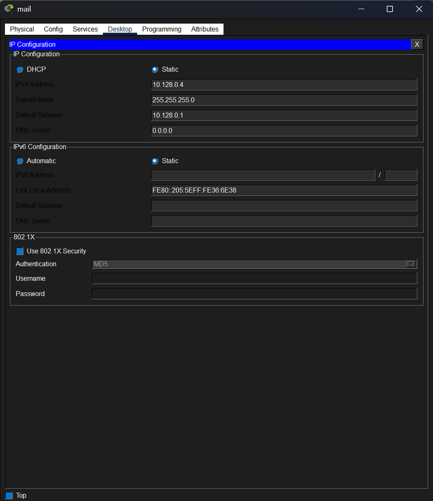

Рисунок 14: Настройка IP-адресации на сервере Mail

## Настройка IP-адресации на клиентском устройстве dk-donskaya-1

- Устройство в **VLAN 101 (dk)**
- **IP-адрес:** 10.128.3.2
- **Маска подсети:** 255.255.255.0
- **Шлюз по умолчанию:** 10.128.3.1
- Подключено к `msk-donskaya-sw-4` (порт Fa0/1)

[figure not shown]

Рисунок 15: Настройка IP-адресации на dk-donskaya-1

## Настройка IP-адресации на клиентском устройстве dep-donskaya-1

- Устройство в **VLAN 102 (departments)**
- **IP-адрес:** 10.128.4.2
- **Маска подсети:** 255.255.255.0
- **Шлюз по умолчанию:** 10.128.4.1
- Подключено к `msk-donskaya-sw-4` (порт Fa0/6)

[figure not shown]

Рисунок 16: Настройка IP-адресации на dep-donskaya-1

## Настройка IP-адресации на клиентском устройстве adm-donskaya-1

- Устройство в **VLAN 103 (adm)**
- **IP-адрес:** 10.128.5.2
- **Маска подсети:** 255.255.255.0
- **Шлюз по умолчанию:** 10.128.5.1
- Подключено к `msk-donskaya-sw-4` (порт Fa0/11)

[figure not shown]

Рисунок 17: Настройка IP-адресации на adm-donskaya-1

## Настройка IP-адресации на клиентском устройстве other-donskaya-1

- Устройство в **VLAN 104 (other)**
- **IP-адрес:** 10.128.6.2
- **Маска подсети:** 255.255.255.0
- **Шлюз по умолчанию:** 10.128.6.1
- Подключено к `msk-donskaya-sw-4` (порт Fa0/16)

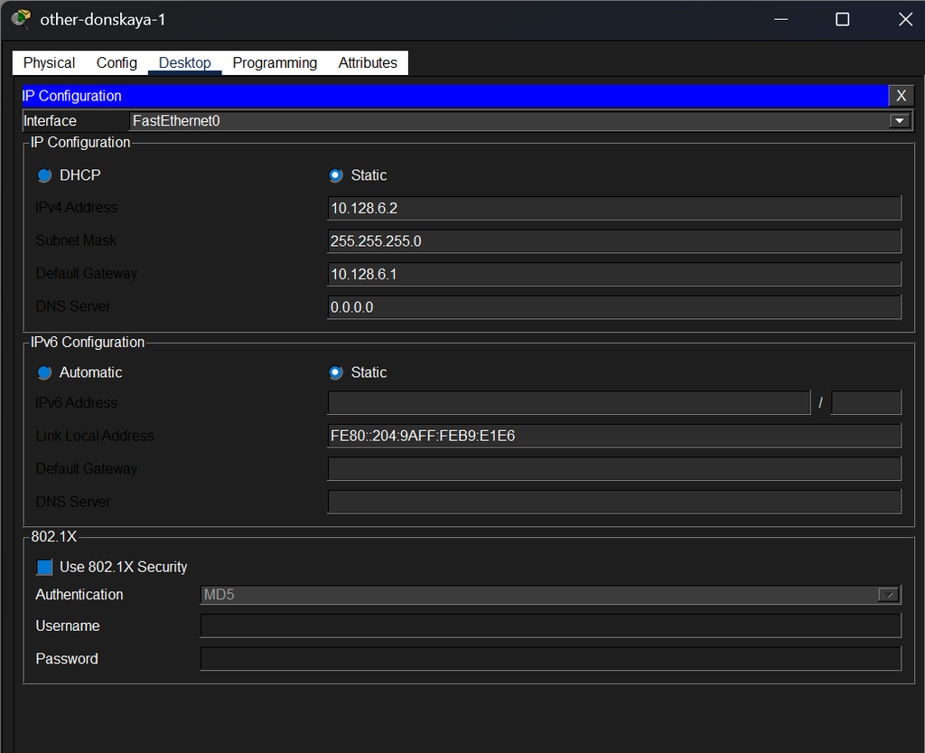

Рисунок 18: Настройка IP-адресации на other-donskaya-1

## Настройка IP-адресации на клиентском устройстве dk-pavlovskaya-1

- Устройство в **VLAN 101 (dk)** (площадка “Павловская”)
- **IP-адрес:** 10.128.3.10
- **Маска подсети:** 255.255.255.0
- **Шлюз по умолчанию:** 10.128.3.1
- Подключено к `msk-pavlovskaya-sw-1` (порт Fa0/1)

[figure not shown]

Рисунок 19: Настройка IP-адресации на dk-pavlovskaya-1

## Настройка IP-адресации на клиентском устройстве other-pavlovskaya-1

- Устройство в **VLAN 104 (other)** (площадка “Павловская”)
- **IP-адрес:** 10.128.6.10
- **Маска подсети:** 255.255.255.0
- **Шлюз по умолчанию:** 10.128.6.1
- Подключено к `msk-pavlovskaya-sw-1` (порт Fa0/20)

[figure not shown]

Рисунок 20: Настройка IP-адресации на other-pavlovskaya-1

# Проверка доступности устройств (Результаты тестирования)

## Анализ работы протокола STP в сети

- Проверка работы протокола **STP (Spanning Tree Protocol)**
- В Simulation Panel отображается обмен **BPDU-кадрами** между коммутаторами
- STP автоматически определяет:
  - **Корневой коммутатор (Root Bridge)**
  - **Корневые порты (Root Ports)**
  - **Назначенные порты (Designated Ports)**
- Блокирует избыточные соединения для предотвращения петель
- Обеспечивает стабильную работу сети и предотвращает широковещательные штормы

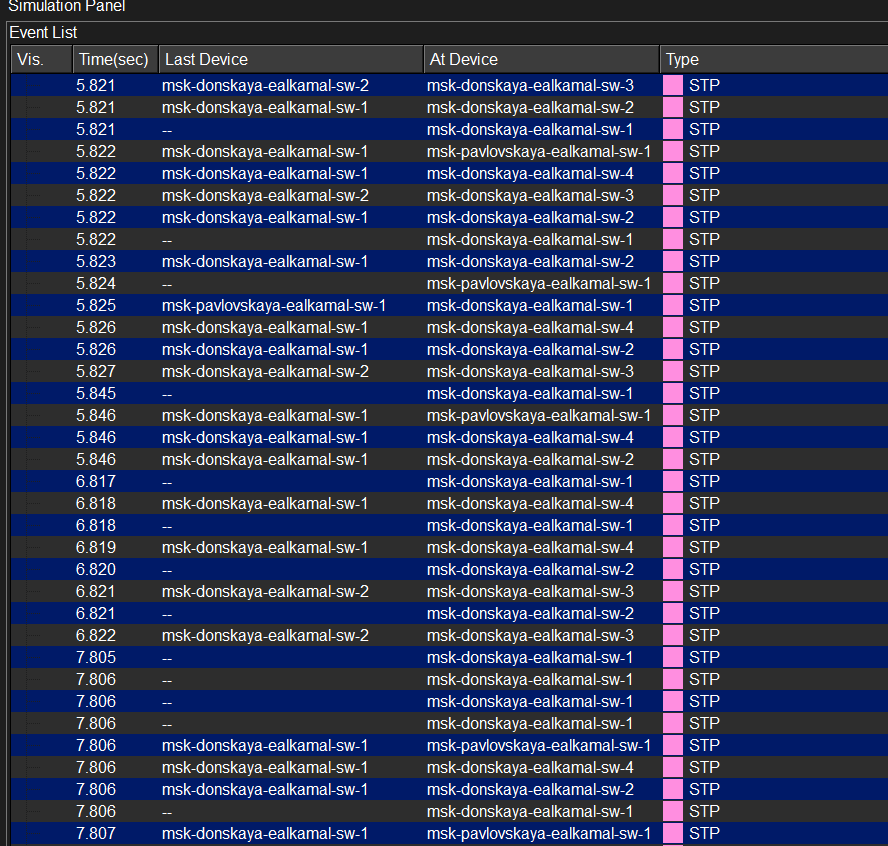

Рисунок 21: Обмен STP сообщениями между коммутаторами

# Выводы

**Выполнены следующие задачи:** - Настройка Trunk-портов между коммутаторами - Настройка VTP-сервера и VTP-клиентов - Создание необходимых VLAN (2, 3, 101-104) - Назначение Access-портов в соответствующие VLAN - Настройка IP-адресации на серверах и ПК

**Все поставленные задачи выполнены успешно.**